# Question

A ship sailed 6.9 miles in a direction of 36° North of East. The ship turned and sailed 5.3 miles in a direction 78° North of East.

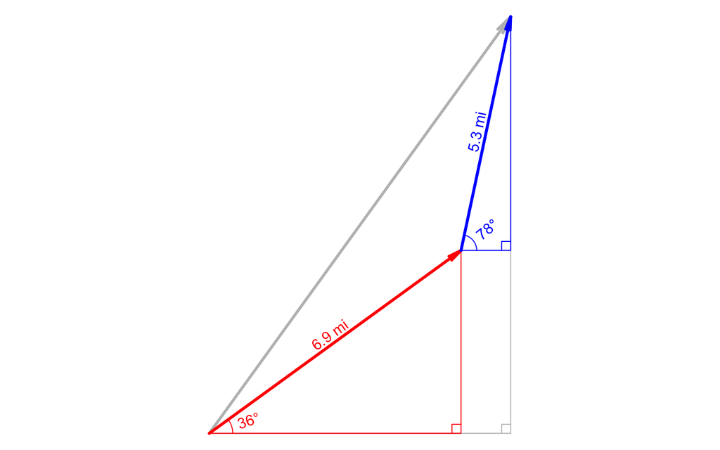

The ship’s captain suffers a terrible accident. The first officer radios for help and sets anchor, waiting for help while administering first aid.

A helicopter, starting where the ship started, wishes to fly directly to the ship. What direction ($\theta$ rounded to nearest degree) and distance ($r$ rounded to nearest tenth of a mile) should the helicopter fly?

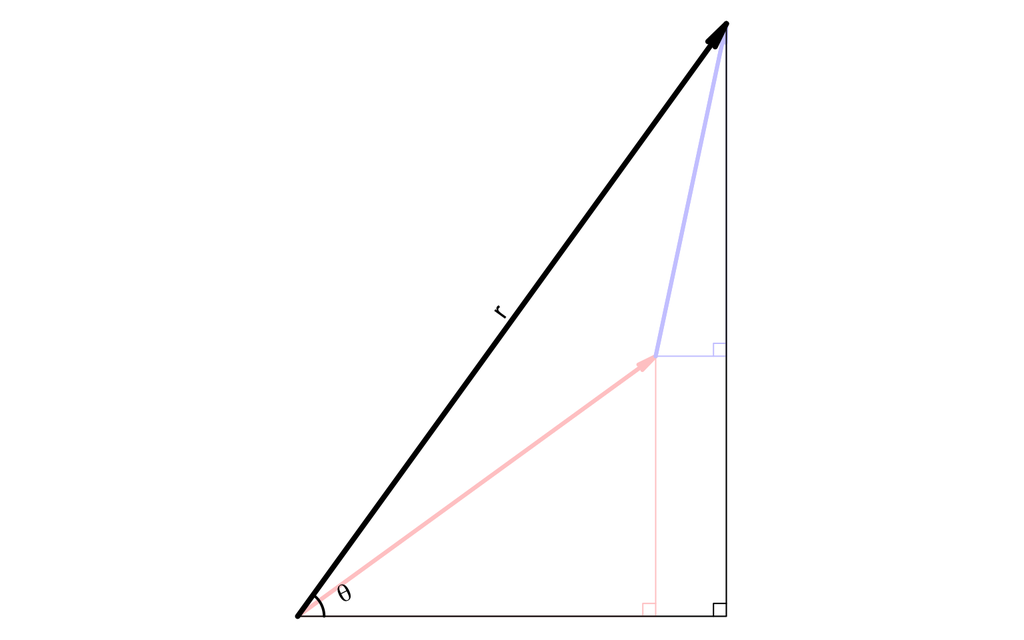

- The direction: $\theta =$ ##ANSWER1##
- The distance: $r =$ ##ANSWER2##

## Answerlist

- 52°
- 53°
- 54°
- 55°
- 56°
- 57°
- 58°
- 59°
- 10.8 mi
- 10.9 mi
- 11.0 mi
- 11.1 mi
- 11.2 mi
- 11.3 mi
- 11.4 mi
- 11.5 mi

# Solution

Start by naming some lengths (the legs of the two small triangles).

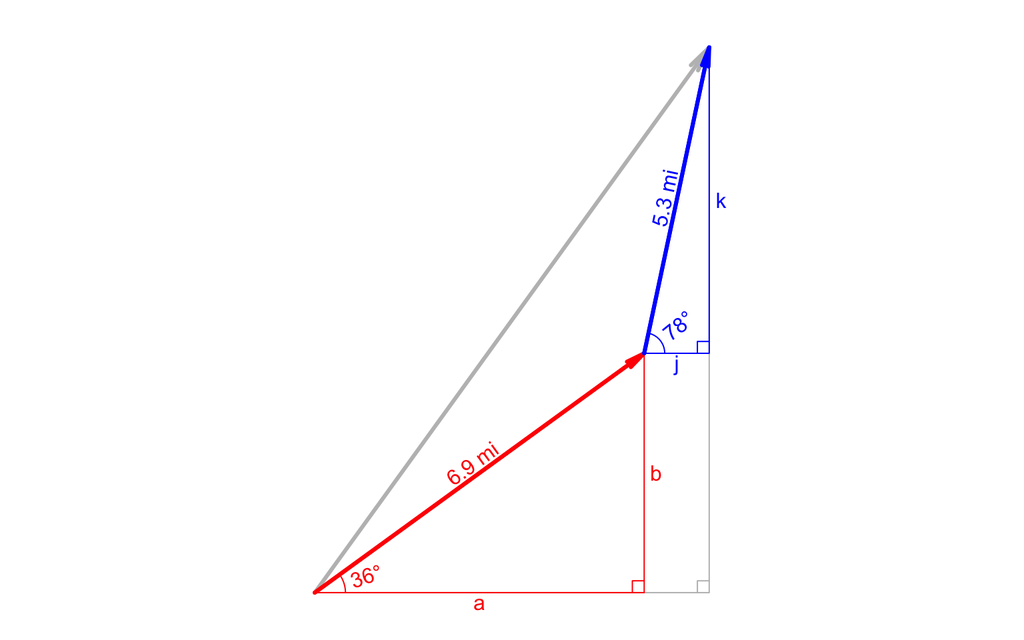

Evaluate $a$, $b$, $j$, and $k$. Remember to set your calculator to DEGREE MODE.

$$a ~=~ 6.9 \cos(36^\circ) ~=~
5.5822173$$
$$b ~=~ 6.9 \sin(36^\circ)
~=~ 4.0557182$$
$$j ~=~ 5.3
\cos(78^\circ) ~=~ 1.101932$$
$$k ~=~
5.3 \sin(78^\circ) ~=~ 5.1841823$$

Name the lengths of the large triangle.

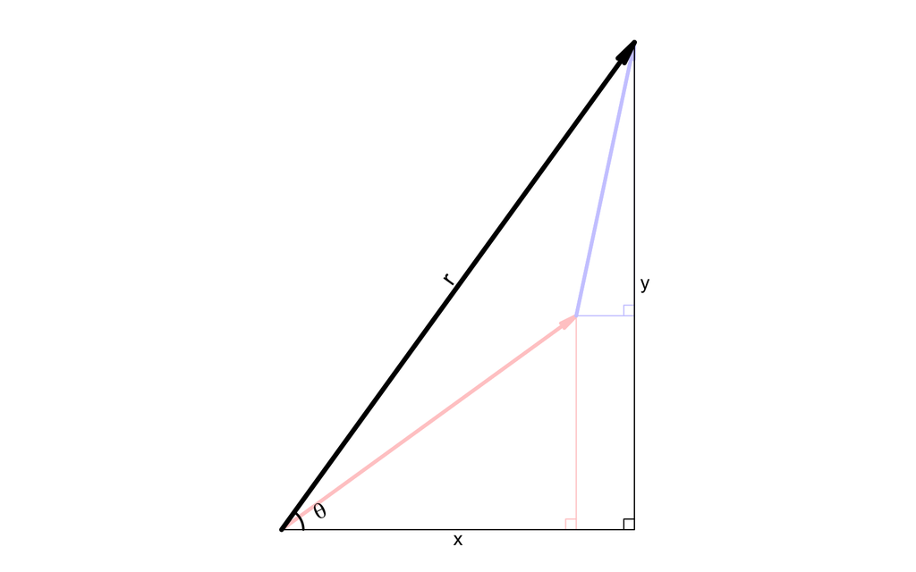

Calculate $x$ and $y$.

$$x~=~5.5822173+1.101932~=~6.6841492$$
$$y~=~4.0557182+5.1841823~=~9.2399005$$
Calculate $\theta$. Remember to set your calculator to DEGREE MODE.

$$\theta ~=~
\arctan\left(\frac{9.2399005}{6.6841492}\right) ~=~ 54.1180017^\circ
~\approx~ 54^\circ$$

Calculate $r$ by using [Pythagorean Theorem](https://en.wikipedia.org/wiki/Pythagorean_theorem).

$$r ~=~ \sqrt{6.6841492^2+9.2399005^2} ~=~
11.4041051 ~\approx~ 11.4 ~\mathrm{mi}$$

Instead of using Pythagorean Theorem, you could have used trigonometry.

$$r ~=~
\frac{6.6841492}{\cos(54.1180017^\circ)} ~=~
\frac{9.2399005}{\sin(54.1180017^\circ)} ~=~ 11.4041051 ~\approx~
11.4~\mathrm{mi}$$

# Meta-information

extype: cloze exclozetype: schoice|schoice exsolution: 00100000|00000010 exname: polar_vector_add_simple